# Scatterplot Matrices & Heatmap & Parallel Coordinates

```python
import pandas as pd
from pandas.plotting import scatter_matrix
from pandas.plotting import parallel_coordinates
import seaborn as sns
import altair as alt

import numpy as np
```

```python
#Switch to Jupyter Notebook mode of matplotlib (pandas is using matplotlib for the scatterplot matrix)
%matplotlib inline

sns.set(style="ticks") # use ticks on plot axes

# Starting with altair v4, enabling a notebook renderer is no longer necessary: alt.renderers.enable('notebook')
alt.__version__
```

```
'4.1.0'
```

## Dataset

```python
# Load the pokemon/fifa dataset
df_data = pd.read_csv('./pokemon.csv')
# More infomation about the dataset: https://www.kaggle.com/rounakbanik/pokemon

#df_data = pd.read_csv('./FIFA19_players.csv')
# More infomation about the dataset: https://www.kaggle.com/karangadiya/fifa19
```

```python
# Inspect the dataset
# See https://pandas.pydata.org/pandas-docs/stable/reference/frame.html
df_data.dtypes # No semicolon to see the output in the notebook
```

```
abilities             object
against_bug          float64
against_dark         float64
against_dragon       float64
against_electric     float64
against_fairy        float64
against_fight        float64
against_fire         float64
against_flying       float64
against_ghost        float64
against_grass        float64
against_ground       float64
against_ice          float64
against_normal       float64
against_poison       float64
against_psychic      float64
against_rock         float64
against_steel        float64
against_water        float64
attack                 int64
base_egg_steps         int64
base_happiness         int64
base_total             int64
capture_rate          object
classfication         object
defense                int64
experience_growth      int64
height_m             float64
hp                     int64
japanese_name         object
name                  object
percentage_male      float64
pokedex_number         int64
sp_attack              int64
sp_defense             int64
speed                  int64
type1                 object
type2                 object
weight_kg            float64
generation             int64
is_legendary           int64
dtype: object
```

```python
# Take a glimpse into the data
df_data.head() # No semicolon to see the output in the notebook
#df_data.loc[df_data['type1'] == "steel"]
```

|  | abilities | against_bug | against_dark | against_dragon | against_electric | against_fairy | against_fight | against_fire | against_flying | against_ghost | ... | percentage_male | pokedex_number | sp_attack | sp_defense | speed | type1 | type2 | weight_kg | generation | is_legendary |
| --- | --- | --- | --- | --- | --- | --- | --- | --- | --- | --- | --- | --- | --- | --- | --- | --- | --- | --- | --- | --- | --- |
| 0 | ['Overgrow', 'Chlorophyll'] | 1.0 | 1.0 | 1.0 | 0.5 | 0.5 | 0.5 | 2.0 | 2.0 | 1.0 | ... | 88.1 | 1 | 65 | 65 | 45 | grass | poison | 6.9 | 1 | 0 |
| 1 | ['Overgrow', 'Chlorophyll'] | 1.0 | 1.0 | 1.0 | 0.5 | 0.5 | 0.5 | 2.0 | 2.0 | 1.0 | ... | 88.1 | 2 | 80 | 80 | 60 | grass | poison | 13.0 | 1 | 0 |
| 2 | ['Overgrow', 'Chlorophyll'] | 1.0 | 1.0 | 1.0 | 0.5 | 0.5 | 0.5 | 2.0 | 2.0 | 1.0 | ... | 88.1 | 3 | 122 | 120 | 80 | grass | poison | 100.0 | 1 | 0 |
| 3 | ['Blaze', 'Solar Power'] | 0.5 | 1.0 | 1.0 | 1.0 | 0.5 | 1.0 | 0.5 | 1.0 | 1.0 | ... | 88.1 | 4 | 60 | 50 | 65 | fire | NaN | 8.5 | 1 | 0 |
| 4 | ['Blaze', 'Solar Power'] | 0.5 | 1.0 | 1.0 | 1.0 | 0.5 | 1.0 | 0.5 | 1.0 | 1.0 | ... | 88.1 | 5 | 80 | 65 | 80 | fire | NaN | 19.0 | 1 | 0 |

5 rows × 41 columns

Hint: Pandas offers [dropna](https://pandas.pydata.org/pandas-docs/stable/reference/api/pandas.DataFrame.dropna.html) function to filter out missing data.

## **Student Information**

Name: **Simon Sternbauer**

Student ID: **k11812499**

## **Task: Scatterplot Matrix**

### Simple Scatterplot Matrix

Select more than two attributes that are suitable and create a scatterplot matrix (e.g., with [pandas](https://pandas.pydata.org/pandas-docs/stable/reference/api/pandas.plotting.scatter_matrix.html) or [altair](https://altair-viz.github.io/gallery/scatter_matrix.html)).

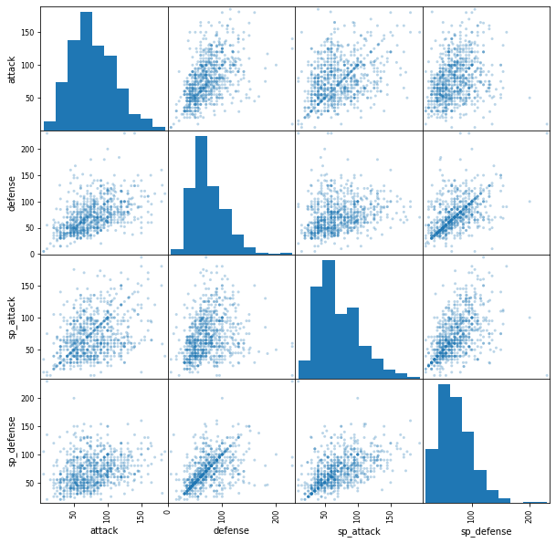

```python
df = df_data[['attack', 'defense', 'sp_attack', 'sp_defense']] # Select values to be displayed
pd.plotting.scatter_matrix(
    df,
    alpha=0.3, # Transparency value for single data point
    figsize=(10, 10) #Increase size
);
```

### Colored Scatterplot Matrix

Select a categorical attribute and encode its values with color in the scatterplot matrix (e.g. with [altair](https://altair-viz.github.io/gallery/scatter_matrix.html) again or [seaborn pairplot](https://seaborn.pydata.org/generated/seaborn.pairplot.html#seaborn.pairplot)).

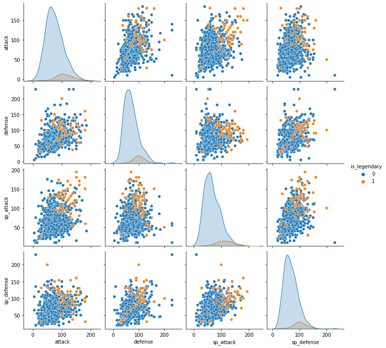

```python
sns.pairplot( # No need to preselect values here, they are selected by the x/y variable names
    df_data,
    x_vars=['attack', 'defense', 'sp_attack', 'sp_defense'],
    y_vars=['attack', 'defense', 'sp_attack', 'sp_defense'],
    hue='is_legendary' # Highlights points when the pokemon is legendary
);
```

### Interpretation

1. The bigger insight that was gained from the second plot is that legendary pokemon do typically have a higher ration of attack/defense and sp_attack/sp_defense than "normal" pokemon. This can especially be seen in the diagonals that the peak for the legendary pokemon is way more to the right. There are obviously some outliers which do have very low values for all values, yet they are far away from forming a majority. Overall, there are way more "normal" pokemon than legendary pokemon
2. Most data is cluttered around the center at around 75 points for all data and not clearly linear. However, in the simple scatterplot matrix it can be observed quite well that there is a very direct link between attack and sp_attack as well as between defense and sp_defense as they definitly form some sort of diagonal with the same value for both "normal" and "special" attack values.

## **Task: Heat Map**

Select suitable attributes and visualise the data in a heatmap, e.g. with [seaborn](https://seaborn.pydata.org/generated/seaborn.heatmap.html) or [altair](https://altair-viz.github.io/gallery/simple_heatmap.html).  
Do not create a correlation heatmap. Correlations can already be read from the scatterplot matrix.

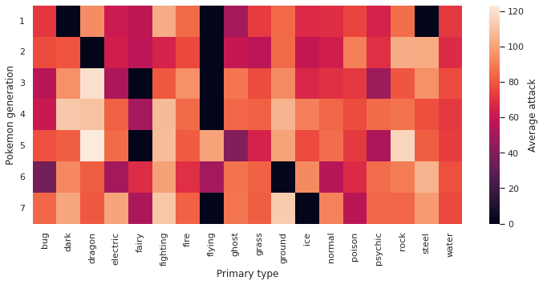

```python
# First select only needed columns
pok_data = df_data[['generation', 'type1', 'attack']]
# Transform into a pivot table and aggregate the mean of the attack values for each primary type in each generation
pok_data = pd.pivot_table(pok_data, columns=['type1'], index=['generation'], values=['attack'], aggfunc=np.mean, fill_value=0)

sns.set(rc = {'figure.figsize':(12,5)}) # Set larger figure size
ax = sns.heatmap(pok_data, cbar_kws={'label': 'Average attack'}); # Create heatmap and set cbar label
ax.set(xlabel='Primary type', ylabel='Pokemon generation') # Set x label
ax.set_xticklabels(pok_data.columns.get_level_values('type1').to_list()); # Set ticks for xlabel with type names
ax.set_yticklabels(ax.get_yticklabels(), rotation = 0); # Set ylabels to not be rotated 90 degrees
sns.reset_orig(); #Reset figure size to avoid troubles with upcomming charts
```

### Interpretation

1. Pokemon with the primary type flying are hardly present, in total only in Gen5 and Gen6 creatures have this as their primary type and then with rather low average attack in Gen 6. On the opposite, quite a handfull of types have had pokemon as their primary type throughout all of the generations
2. Primary type dragons have rather high average attack, especially in Gen 3 and Gen 5, not counting their absence in Gen 2. Solid values can be accounted for water and rock type pokemon.

## **Task: Parallel Coordinates**

Select a categorical attribute and encode the lines with color in the parallel coordinates chart. (e.g. with [pandas](https://pandas.pydata.org/pandas-docs/stable/reference/api/pandas.plotting.parallel_coordinates.html) or [altair](https://altair-viz.github.io/gallery/parallel_coordinates.html)).

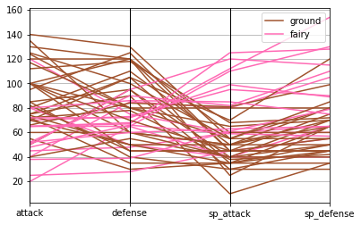

```python
# Filter data first, only take fairy and ground type1 pokemon that are not legendary (avoid outliers)
pok_data = df_data[((df_data['type1'] == 'fairy')  | (df_data['type1'] == 'ground')) & (df_data['is_legendary'] == 0)]

# Plot pokemon stats in regards of their (special) attack / defense
par_plot = pd.plotting.parallel_coordinates(
    pok_data,
    'type1', # Attribute for parallel coordinates
    cols=['attack', 'defense', 'sp_attack', 'sp_defense'], # Columns for which the different values are shown
    color=('#A0522D', '#FF69B4') # Color for the axis
);
```

### Interpretation

1. Ground pokemon do typically have rather high attack and defense values compared to fairy type pokemon, although the values are much more spreaded in these two columns. Ground pokemons do have rather low special attack values and also not too high special defense (no wonder, they typically do physical attacks in the games).
2. Fairy type pokemon put more effort into higher values for special attack and also defense, even though there are some scattered values which are rather low. Overall, the normal attack is quite on the lower side, the defense as well, even though it is a bit better

Additional note: It was rather hard to construct a scenarion which has meaningfull data to show. First I tried to go for the attack some types over the different generations, but this turned out to be very confusing. Also plotting the (special) attack/defense for different types in one generation turned out to be a rather bad idea. Therefore I settled for the comparison of two types in the end with regards to their (special) attack/defense and tried to colour it nicely

## **Submission**

Please add your student information (name,student ID) and download this notebook as HTML (File > Export Notebook As... > Export Notebook to HTML) and submit it.